# Project Assignment 1 - Week 2

Leonardo Silveira

April 7, 2019

In this assignment we will analyze data from a personal activity monitoring device.

The device collects data at 5 minutes intervals through out the day.

First thing we’ll do is to load some packages we need and then we’ll read in the data collected from an anonymous individual

```r
library(lubridate)
```

```r
library(ggplot2)
library(dplyr)
data1 <- read.csv("activity.csv", header = TRUE)
```

## What is mean total number of steps taken per day?

Since we already have our data, we are going to do some operations:

1 - Put the date column in date type

2 - group the data we have by date

3 - calculate the sum of steps taken each day

```r
# transforming to date type
data1$date <- ymd(data1$date)

# grouping by data
data2 <- filter(data1, is.na(steps) == FALSE)
data3 <- group_by(data2, date)
# calculating the total number of steps taken each day
data3 <- summarise(data3, sum(steps))
# renaming my column
data3 <- rename(data3, total_steps =`sum(steps)`)
```

With this we can now plot a histogram of the sum of steps taken each day AND calculate some summary of the data - mean and median

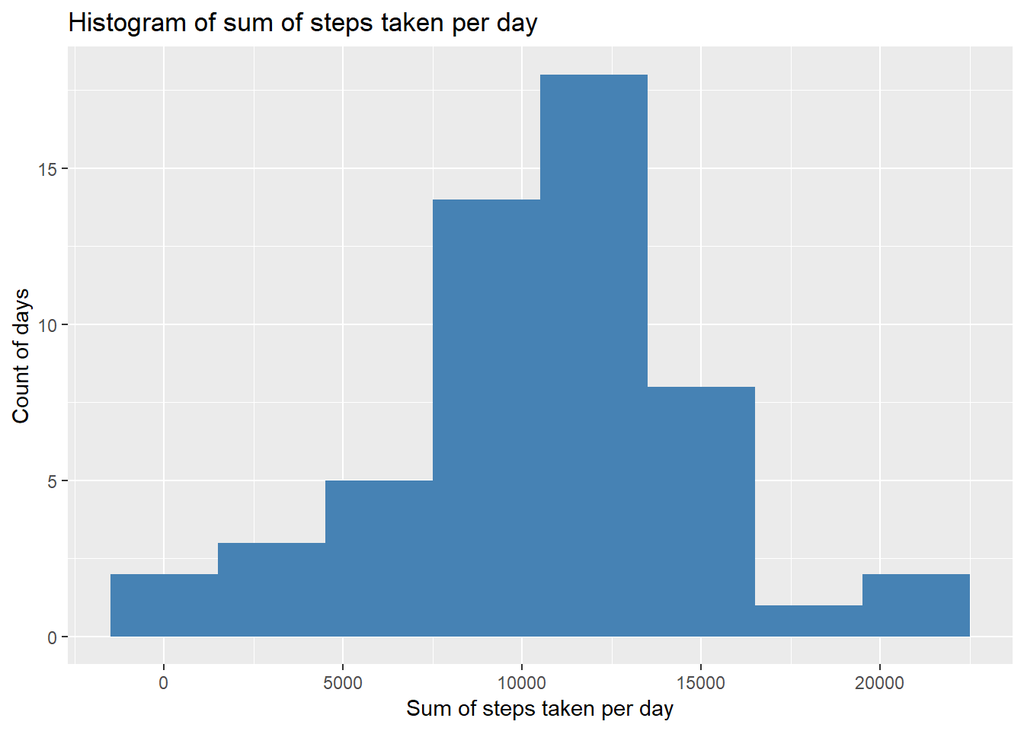

```r
ggplot(data3, aes(total_steps)) + geom_histogram(binwidth = 3000, fill = "steelblue") + labs(title = "Histogram of sum of steps taken per day", y = "Count of days", x = "Sum of steps taken per day")
```

```r
mean(data3$total_steps)
```

```
## [1] 10766.19
```

```r
median(data3$total_steps)
```

```
## [1] 10765
```

## What is the average daily activity pattern?

In this point we want to plot the average activity throughout the day.  
To acchieve this we will group our data by the interval variable and then calculate the average of the steps taken in each interval.  
We also will print the maximum average value of steps

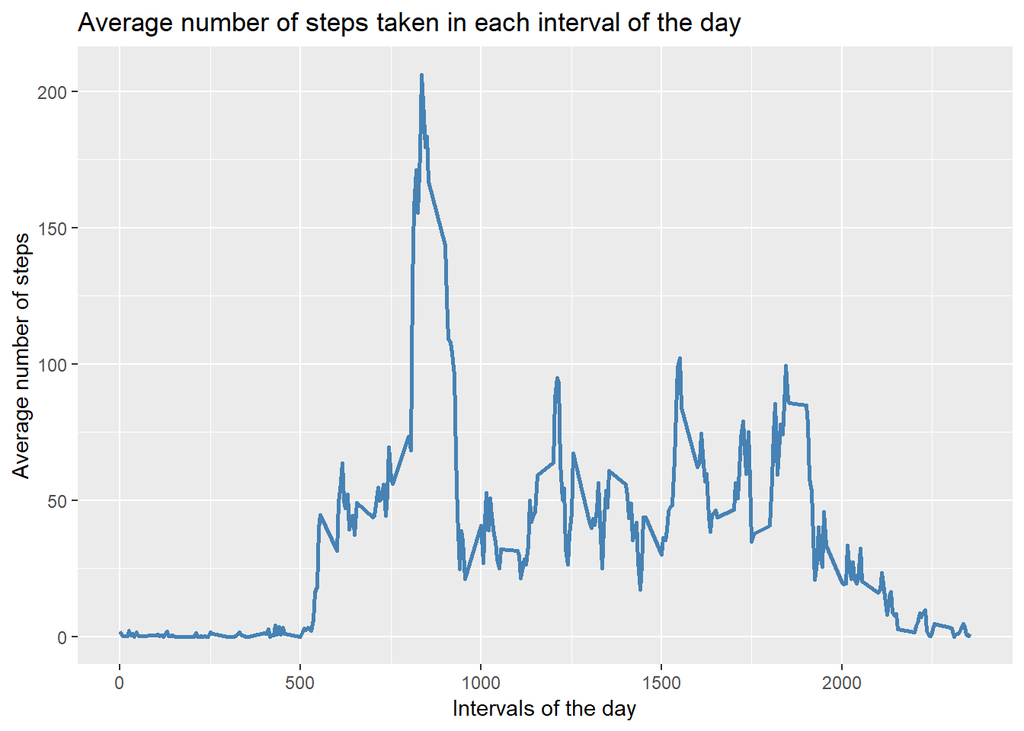

```r
by_interval <- group_by(data2, interval)
by_interval <- summarise(by_interval, mean(steps))
by_interval <- rename(by_interval, average = `mean(steps)`)

ggplot(by_interval, aes(interval, average)) + geom_line(color = "steelblue", size = 1) + labs(title = "Average number of steps taken in each interval of the day", y = "Average number of steps", x = "Intervals of the day")
```

```r
pos_max <- which.max(by_interval$average)
by_interval[pos_max,]
```

```
## # A tibble: 1 x 2
##   interval average
##      <int>   <dbl>
## 1      835    206.
```

## Imputing missing values

First we calculate the total number of missing values

```r
sum(is.na(data1$steps))
```

```
## [1] 2304
```

Now we will fill out of the NA values with the average number of steps taken in that 5-minutes interval  
We will do this in a data frame called data_filled

After that we will plot a new histogram of the sum of steps taken per day, and calculate the average and median number of steps taken per day - with the new plot and the new summaries, we will compare the results with what we got analysing the data with NAs in it

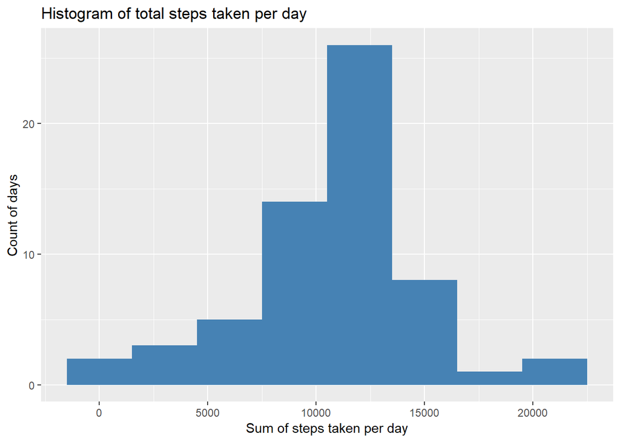

```r
# strategy for filling all the missing data values
# fill missing data with average number of steps taken in that 5-minute interval
data_filled <- data1

for (i in 1:nrow(data1)) {


        if(is.na(data1$steps[i])){

                value <- subset(by_interval, by_interval$interval == data1$interval[i])
                data_filled$steps[i] <- value$average

        }

}

# calculating the histogram, but now with the NAs filled out

data_filled$date <- ymd(data_filled$date)
filled2 <- group_by(data_filled, date)
filled2 <- summarise(filled2, sum(steps))
filled2 <- rename(filled2, total_steps =`sum(steps)`)


ggplot(filled2, aes(total_steps)) + geom_histogram(binwidth = 3000, fill = "steelblue") + labs(title = "Histogram of total steps taken per day", y = "Count of days", x = "Sum of steps taken per day")
```

```r
mean(filled2$total_steps)
```

```
## [1] 10766.19
```

```r
median(filled2$total_steps)
```

```
## [1] 10766.19
```

We see that the mean value of the total number of steps taken each day continues the same as before.  
The median had a slight change, and now has the same value as the mean.

Imputing missing values does not have any major impact in the results for this dataset.

## Are there differences in activity patterns between weekdays and weekends?

We want to see the mean of the steps taken in each 5-minutes interval, but now comparing the activity between weekdays and days of the weekend.

To do that the first thing we need to do is to identify what day of the week the date variable represents - for this we create two new variables: one with the name of the day of week, and the other with the number this day represent

Then we create a variable saying if that day of week is in the Weekend or in the Week

```r
# creating a variable that says the day of the week of that day
# weekends account for 1 (monday) and 7 (satuday)

data_filled$name_day <- weekdays(data_filled$date)
data_filled$number_day <- wday(data_filled$date)

# a factor variable describing if the day is weekend or not

for (i in 1:nrow(data_filled)) {

        if(data_filled$number_day[i] != 1 & data_filled$number_day[i] != 7){
                data_filled$period[i] = "week"
        }else{
                data_filled$period[i] = "weekend"
        }

}

# changing the variable period to factor

data_filled$period <- as.factor(data_filled$period)
```

Now that we have our data with the variable period (week or weekend), we can aggregate the average of the steps taken in each 5-minute interval by the factor period.

After that we plot the panel with this information using ggplot2

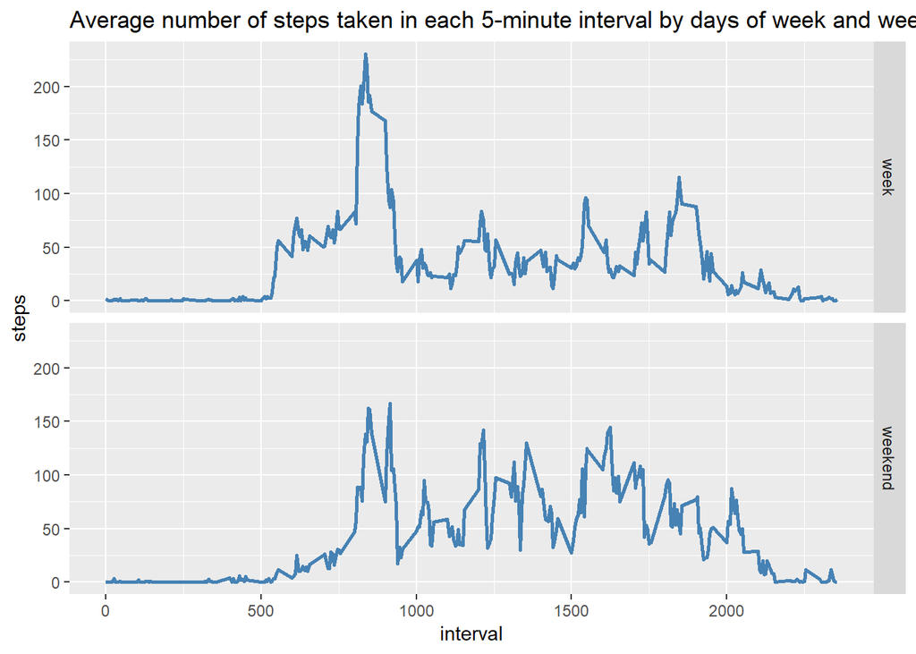

```r
# calculating the mean for each 5-minute interval for week and weekend

data_agg <- aggregate(steps ~ interval + period, data_filled, mean)

# plotting the panel

ggplot(data_agg, aes(interval, steps)) + geom_line(color = "steelblue", size = 1) + facet_grid( period ~ .) + labs(title = "Average number of steps taken in each 5-minute interval by days of week and weeking")
```

And now we are done. :)